# LDA implementations in R and Python

Where tidylda sits in the ecosystem

## What this measures

Color encodes the algorithm family. Engine names are labeled directly on the curves.

Corpora

| Corpus | Documents | Terms | Tokens | Mean doc length |
| --- | --- | --- | --- | --- |
| ap | 2,242 | 9,172 | 424,341 | 189.3 |
| 20ng | 17,669 | 20,926 | 1,456,595 | 82.4 |

## Headline findings

**3. Model quality is broadly a wash.** Apart from gensim and scikit-learn, which fit noticeably worse, the engines land on top of each other on both coherence and R² — by margins comparable to the run-to-run noise. Read the quality columns as a cluster, not a ranking.

[figure not shown]

[figure not shown]

Swing in mean coherence across 1-12 threads. Lower is more reproducible.

| Engine | AP (2.2k docs) | 20 Newsgroups (17.7k docs) |
| --- | --- | --- |
| bigartm | 0.0% | 0.0% |
| gensim | 7.0% | 28.8% |
| mallet | 6.8% | 9.5% |
| sklearn | 13.8% | 8.1% |
| tidylda | 0.0% | 0.0% |
| tomotopy | 4.1% | 4.0% |

## 1. Quality against wall-clock time

The headline result. A Gibbs sweep and a variational pass are different units of work, so comparing “200 iterations each” would compare two arbitrary numbers. Instead each engine is run at a ladder of iteration counts, single threaded, and we plot the quality it reached against how long it took. **Down and to the right is worse; up and to the left is better.** A curve that sits above and to the left of another dominates it.

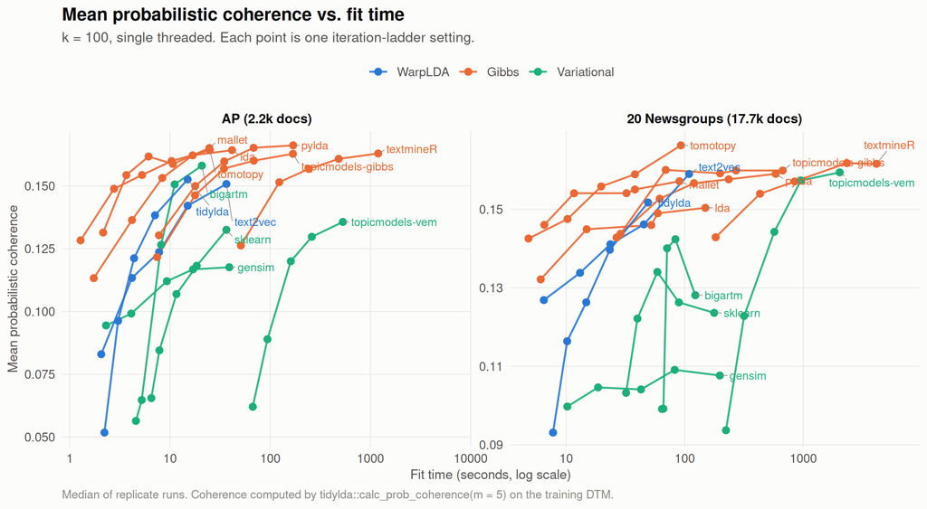

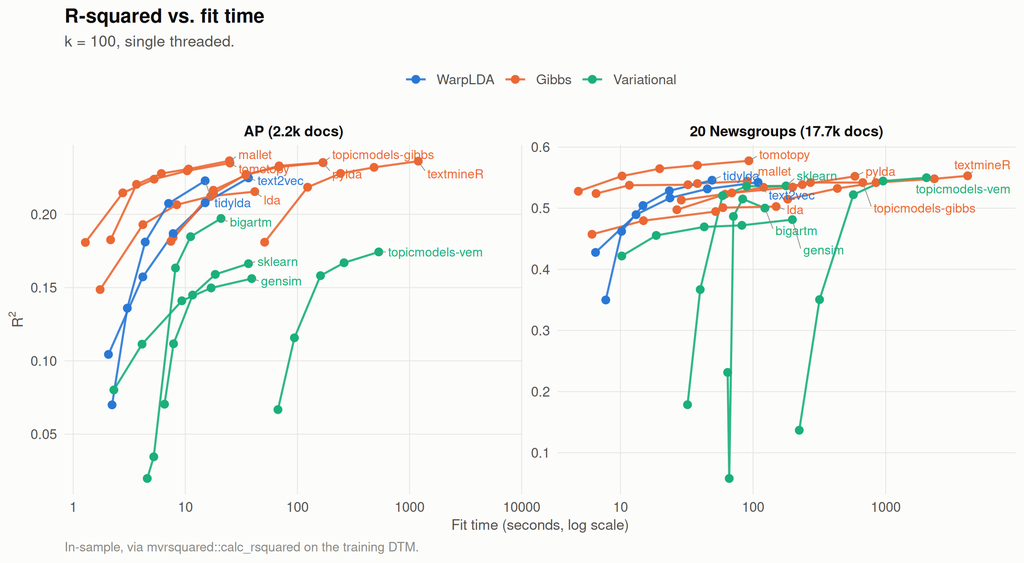

**A note on reading the quality axes.** Re-running the same engine on the same configuration with a different seed moves mean coherence by up to 0.0104 (median 0.0039). The whole spread across the nine clustered engines is 0.0159 — barely above that, and less than a fifth of the topic-to-topic standard deviation within a single model (median 0.0891). So vertical ordering among the clustered curves is not a finding. What survives is the bottom: gensim and scikit-learn fit worse on coherence, and gensim and R’s `lda` sit low on R². The two metrics disagree about who the outlier is, which is a further reason to hold the rest loosely.

## 2. Thread scaling

Only some engines thread at all. For those that do, this is speedup relative to their own single-threaded time — so it answers “does adding cores help *this* package”, not “which package is fastest” (that is the chart above).

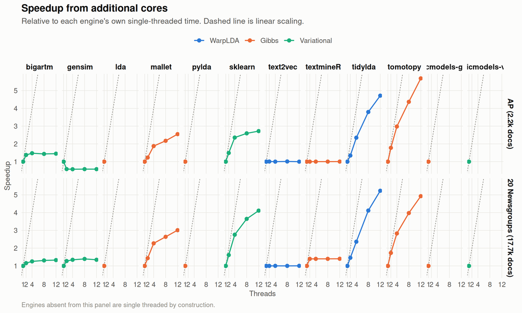

Threading is not free of consequences for every engine. MALLET and tomotopy use parallel samplers that do not preserve the exact collapsed Gibbs chain; tidylda’s is documented to be invariant to thread count, and `scripts/98-verify.R` confirms its parameters are bit-identical at 1 and 20 threads. So it is worth checking whether quality moves as cores are added:

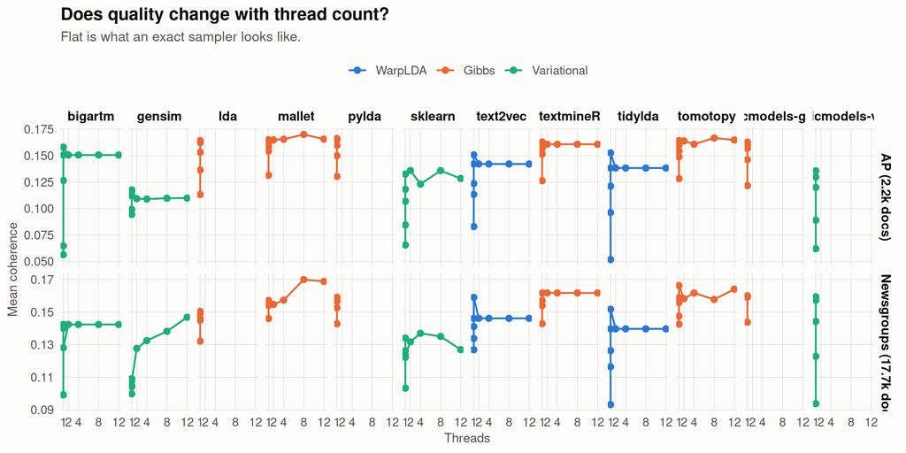

## 3. Memory

Peak resident set size of the whole process, so it includes the interpreter or JVM baseline. The baselines are shown rather than subtracted.

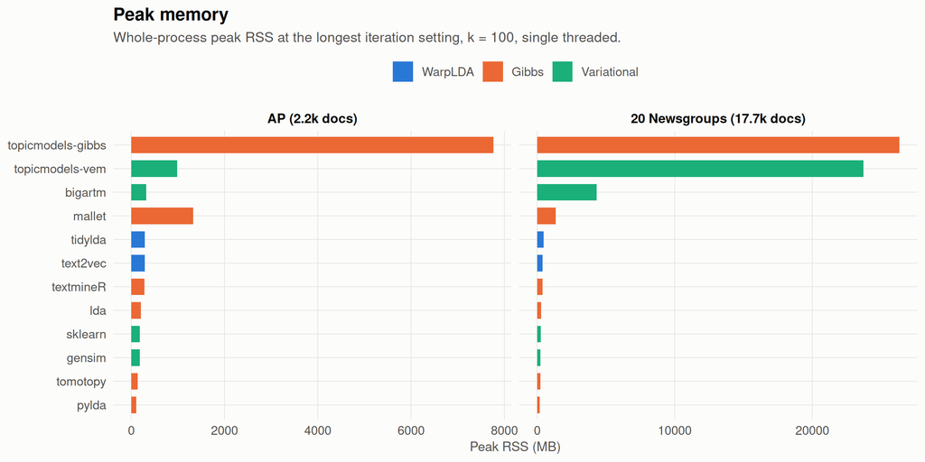

## 4. Quality across topic counts

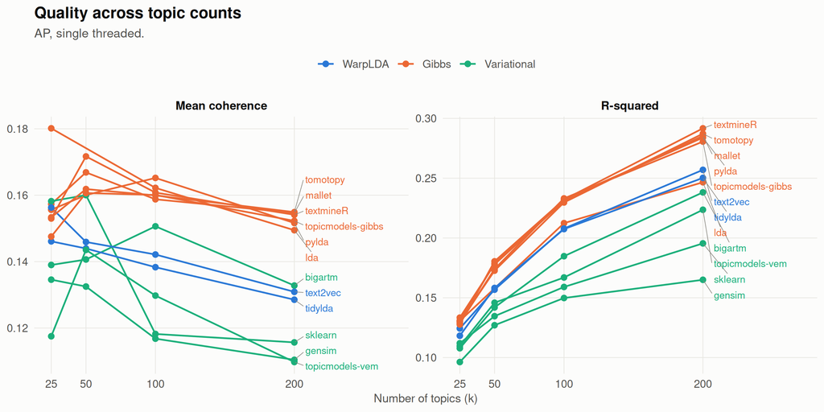

## 5. The numbers

Identity is never carried by color alone: here is every aggregated run.

| Corpus | Engine | Family | k | Iterations | Fit (s) | Peak RSS (MB) | R^2 | Coherence | Reps |
| --- | --- | --- | --- | --- | --- | --- | --- | --- | --- |
| AP (2.2k docs) | bigartm | Variational | 100 | 1 | 4.57 | 323 | 0.0198 | 0.0564 | 3 |
| AP (2.2k docs) | bigartm | Variational | 100 | 2 | 5.22 | 324 | 0.0346 | 0.0648 | 3 |
| AP (2.2k docs) | bigartm | Variational | 100 | 5 | 8.16 | 323 | 0.1634 | 0.1266 | 3 |
| AP (2.2k docs) | bigartm | Variational | 100 | 10 | 11.13 | 324 | 0.1848 | 0.1506 | 3 |
| AP (2.2k docs) | bigartm | Variational | 100 | 25 | 20.79 | 324 | 0.1972 | 0.1581 | 3 |
| AP (2.2k docs) | gensim | Variational | 100 | 1 | 2.30 | 176 | 0.0802 | 0.0944 | 3 |
| AP (2.2k docs) | gensim | Variational | 100 | 2 | 4.11 | 180 | 0.1114 | 0.0992 | 3 |
| AP (2.2k docs) | gensim | Variational | 100 | 5 | 9.31 | 183 | 0.1410 | 0.1121 | 3 |
| AP (2.2k docs) | gensim | Variational | 100 | 10 | 16.98 | 184 | 0.1498 | 0.1168 | 3 |
| AP (2.2k docs) | gensim | Variational | 100 | 25 | 39.09 | 183 | 0.1562 | 0.1176 | 3 |
| AP (2.2k docs) | lda | Gibbs | 100 | 20 | 1.74 | 205 | 0.1487 | 0.1133 | 3 |
| AP (2.2k docs) | lda | Gibbs | 100 | 50 | 4.18 | 206 | 0.1930 | 0.1364 | 3 |
| AP (2.2k docs) | lda | Gibbs | 100 | 100 | 8.38 | 206 | 0.2066 | 0.1532 | 3 |
| AP (2.2k docs) | lda | Gibbs | 100 | 200 | 16.84 | 205 | 0.2124 | 0.1622 | 3 |
| AP (2.2k docs) | lda | Gibbs | 100 | 500 | 41.60 | 206 | 0.2155 | 0.1643 | 3 |
| AP (2.2k docs) | mallet | Gibbs | 100 | 20 | 2.15 | 290 | 0.1826 | 0.1314 | 3 |
| AP (2.2k docs) | mallet | Gibbs | 100 | 50 | 3.67 | 386 | 0.2205 | 0.1543 | 3 |
| AP (2.2k docs) | mallet | Gibbs | 100 | 100 | 6.11 | 585 | 0.2279 | 0.1617 | 3 |
| AP (2.2k docs) | mallet | Gibbs | 100 | 200 | 10.68 | 932 | 0.2309 | 0.1588 | 3 |
| AP (2.2k docs) | mallet | Gibbs | 100 | 500 | 24.73 | 1326 | 0.2365 | 0.1651 | 3 |
| AP (2.2k docs) | pylda | Gibbs | 100 | 20 | 7.76 | 107 | 0.1842 | 0.1304 | 3 |
| AP (2.2k docs) | pylda | Gibbs | 100 | 50 | 17.82 | 111 | 0.2143 | 0.1500 | 3 |
| AP (2.2k docs) | pylda | Gibbs | 100 | 100 | 34.80 | 107 | 0.2273 | 0.1598 | 3 |
| AP (2.2k docs) | pylda | Gibbs | 100 | 200 | 68.30 | 110 | 0.2323 | 0.1652 | 3 |
| AP (2.2k docs) | pylda | Gibbs | 100 | 500 | 169.25 | 108 | 0.2352 | 0.1662 | 3 |
| AP (2.2k docs) | sklearn | Variational | 100 | 1 | 6.52 | 184 | 0.0705 | 0.0655 | 3 |
| AP (2.2k docs) | sklearn | Variational | 100 | 2 | 7.84 | 181 | 0.1117 | 0.0845 | 3 |
| AP (2.2k docs) | sklearn | Variational | 100 | 5 | 11.60 | 182 | 0.1449 | 0.1069 | 3 |
| AP (2.2k docs) | sklearn | Variational | 100 | 10 | 18.47 | 180 | 0.1590 | 0.1182 | 3 |
| AP (2.2k docs) | sklearn | Variational | 100 | 25 | 36.55 | 184 | 0.1663 | 0.1325 | 3 |

[output cut: 90 more lines]

## Environment

```
cores: 24
R: R version 4.6.0 (2026-04-24)
               total        used        free      shared  buff/cache   available
Mem:           125Gi        53Gi        21Gi        18Mi        52Gi        72Gi
Model name:                              Intel(R) Core(TM) i9-10920X CPU @ 3.50GHz
Thread(s) per core:                      2
Core(s) per socket:                      12
Socket(s):                               1
Linux price 6.8.0-134-generic #134-Ubuntu SMP PREEMPT_DYNAMIC Fri Jun 26 18:43:11 UTC 2026 x86_64 x86_64 x86_64 GNU/Linux
```

```
tidylda version: 0.1.0
tidylda source: /home/tommy/tidylda
tidylda git sha: 14e02b7a637c14e159bcc64f555ddfe173918d99
tidylda working tree dirty: FALSE
```

Implementation versions

| Engine | Language | Version |
| --- | --- | --- |
| mallet | Java | 202108 |
| bigartm | Python | 0.9.2 |
| gensim | Python | 4.4.0 |
| pylda | Python | 3.0.2 |
| sklearn | Python | 1.9.0 |
| tomotopy | Python | 0.14.0 |
| lda | R | 1.5.2 |
| text2vec | R | 0.6.6 |
| textmineR | R | 3.0.6 |
| tidylda | R | 0.1.0 |
| topicmodels-gibbs | R | 0.2.17 |
| topicmodels-vem | R | 0.2.17 |